# Definisi Infix, Postfix, Prefix

Prefix, infix, dan postfix adalah suatu cara penulisan ungkapan-ungkapan yang rumit, misalnya pemakaian tanda kurung dalam operasi matematika. Prefix adalah metode penulisan dengan meletakkan operator di depan operand dan tanpa menuliskan tanda kurung. Contoh pemakaian prefix adalah +AB, – +ABC, * + AB – CD. Infix adalah cara penulisan ungkapan dengan meletakkan operator di antara dua operand dalam hal ini pemakaian tanda kurung sangat menentukan hasil operasi. Contoh pemakaian infix adalah A+B, A+B-C, (A+B)*(C-D). Postfix adalah metode penulisan dengan menuliskan operator setelah operand dan tanpa menuliskan tanda kurung. Salah satu contoh proses pengubahan infix menjadi postfix dari karakter: ( A + B ) / (( C – D ) * E ^ F)

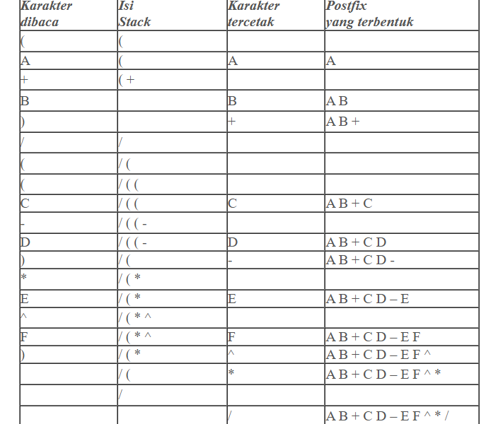

# Notasi Infix To Postfix

Suatu perhitungan aritmatika biasanya berhubungan dengan operand dan operator. Operand merupakan suatu karakter atau elemen yang nilainya dioperasikan dengan bantuan suatu operator untuik menghasilkan suatu solusi. Misalkan jika diberikan suatu ekspresi aritmatika 2 * 3, maka elemen ‘dua’ dan elemen ‘tiga’ merupakan operand dari ekspresi tersebut dan elemen ‘*’ merupakan operator perkalian atas dua operand yang menghasilkan suatu solusi. Suatu ekspresi aritmatika dapat dibedakan dalam tiga bentuk notasi perhitungan yaitu :

1. Notasi prefix, jika operator ditempatkan sebelum dua operand
2. Notasi infix, jika operator ditempatkan diantara dua operand
3. Notasi postfix, jika operator ditempatkan setelah dua operand Dalam penggunaannya, dalam kehidupan sehari-hari notasi infix merupakan notasi aritmatika yang paling banyak digunakan untuk mengekspresikan suatu perhitungan artimatik dibanding dengan dua notasi yang lain, akan tetapi notasi Postfix merupakan notasi yang digunakan oleh mesin kompilasi pada komputer dengan maksud untuk mempermudah proses pengkodean, sehingga mesin kompilasi membutuhkan stack untuk proses translasi ekspresi tersebut.

# Konversi Infix To Postfix

- Jika ditemukan simbol kurung buka “(“ Operasi push pada stack akan digunakan untuk menyimpan simbol tersebut ke dalam stack.
- Jika ditemukan simbol kurung buka “)” Operasi pop digunakan untuk mengeluarkan operator-operator yang berada di dalam stack.
- Jika terdapat simbol operator Jika dalam suatu untai notasi infix ditemukan simbol operator maka operasi yang dilakukan pada stack terbagi atas :
1. Jika TOP(S) dari stack tersebut kosong atau berisi simbol “(“ maka operasi push akan digunakan untuk memasukan operator tersebut pada posisi di TOP(S)
2. Jika operator yang berada dipuncak stack merupakan elemen yang memiliki tingkat yang sama atau lebih tinggi maka operasi pop digunakan untuk mengeluarkan operator tersebut diikuti operasi push untuk menyimpan operator hasil scanning untai.
3. Jika operator yang berada di puncak stack memiliki tingkat yang lebih rendah dari operator yang discan, maka operator baru akan langsung dimasukan ke dalam stack dengan operasi push.

Adapun tingkatan operator yang dilacak menurut urutan tingkat adalah :

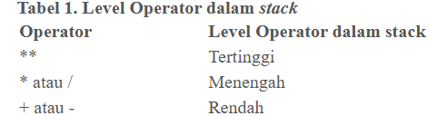

Berikut Implementasi Codenya:

# Contoh Hasil

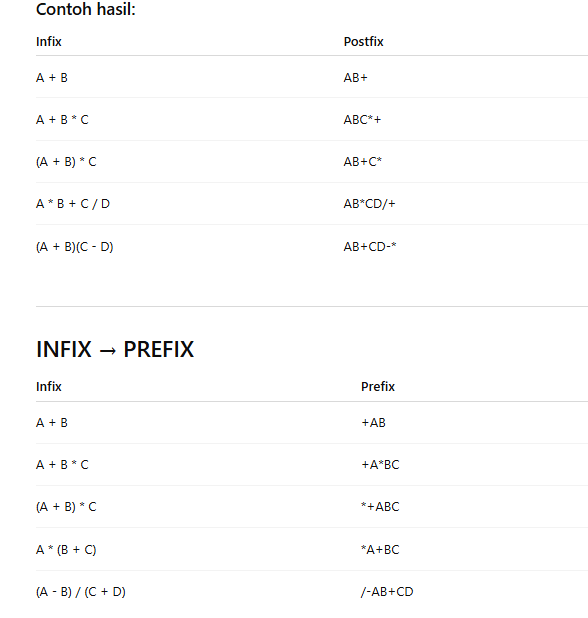

```python
def prec(c):
    if c == '^':
        return 3
    elif c == '/' or c == '*':
        return 2
    elif c == '+' or c == '-':
        return 1
    else:
        return -1

def isRightAssociative(c):
    return c == '^'

def infixToPostfix(s):
    st = []
    res = []

    for c in s:
        # If operand, add to result
        if ('a' <= c <= 'z') or ('A' <= c <= 'Z') or ('0' <= c <= '9'):
            res.append(c)

        # If '(', push to stack
        elif c == '(':
            st.append('(')

        # If ')', pop until '('
        elif c == ')':
            while st and st[-1] != '(':
                res.append(st.pop())
            st.pop()

        # If operator
        else:
            while st and st[-1] != '(' and \
                (prec(st[-1]) > prec(c) or (prec(st[-1]) == prec(c) \
                                    and not isRightAssociative(c))):
                res.append(st.pop())
            st.append(c)

    # Pop remaining operators
    while st:
        res.append(st.pop())

    return ''.join(res)

if __name__ == '__main__':
    exp = "((A * B) + C / D – E ** F) * G;"
    print(infixToPostfix(exp))
```

[output not shown]

# Infix To Prefix

Seperti dalam mengubah infix menjadi postfix, hal yang pertama kita lakukan adalah mengambil operator yang berada pada tingkat paling atas, namun saat ini kita menaruhnya di sebelah kiri.

Lalu kita lanjutkan untuk sub-ekspresi sub-ekspresi selanjutnya sampai tidak ada lagi sub-ekspresi yang bisa ditinjau.

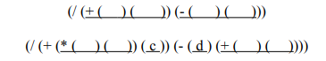

(/ (+ (* ( a ) ( b )) ( c )) (- ( d ) (+ ( e ) ( f ))))

Berikut Implementasi Codenya:

```python
def precedence(c):
    if c == '^':
        return 3
    elif c in ('*', '/'):
        return 2
    elif c in ('+', '-'):
        return 1
    else:
        return -1

# function to check if operator is right-associative
def isRightAssociative(c):
    return c == '^'

# function to check if a character is an operator
def isOperator(c):
    return c in "+-*/^"

# function to convert infix expression to prefix
def infixToPrefix(s):
    st = []
    result = []

    # scan from right to left
    for c in reversed(s):
        if c.isalnum():
            result.append(c)
        elif c == ')':
            st.append(c)
        elif c == '(':
            while st and st[-1] != ')':
                result.append(st.pop())
            if st:
                st.pop()  # remove ')'
        elif isOperator(c):
            while (st and isOperator(st[-1]) and
                  (precedence(st[-1]) > precedence(c) or
                  (precedence(st[-1]) == precedence(c) and isRightAssociative(c)))):
                result.append(st.pop())
            st.append(c)

    # pop remaining operators
    while st:
        result.append(st.pop())

    # reverse at the end to get correct prefix
    return ''.join(reversed(result))

if __name__ == "__main__":
    s = "((a * b) + c) / (d – (e + f))"
    print(infixToPrefix(s))
```

```
/+*abcd+ef
```

# Prefix To Infix

Hampir sama dengan Postfix ke Infix. Untuk mengubah kembali dari prefix maupun postfix menjadi infix, pada dasarnya memiliki metode yang sama dengan infix ke postfix ataupun infix ke prefix, yang perlu diperhatikan hanyalah penempatan operator dan tanda bantunya.

Jika pada prefix operator berada di depan tanda bantu dan pada postfix operator berada di belakang tanda bantu, pada infix operator berada di tengah-tengah tanda bantu.

Hal yang pertama kali kita lakukan adalah menambahkan tanda bantu agar lebih mudah dalam mengubahnya menjadi bentuk lain, dengan cara menambahkan tanda kurung di awal sub-ekspresi, dan menutupnya di akhir sub-ekspresi.

(/ + * a b c – d + e f)

(/ (+ * a b c) – d + e f)

(/ (+ * a b c) (– d + e f))

(/ (+ (* a b) c) (– d + e f))

(/ (+ (* a b) c) (– d (+ e f)))

Setelah terbentuk persamaan dengan tanda bantu, maka lebih mudah untuk mengubahnya menjadi infix.

Caranya sama seperti mengubah infix menjadi postfix maupun prefix, namun kali ini operatornya kita tempatkan di tengah-tengah kedua tanda kurung.

(( ) / ( ))

((( ) + ( )) / (( ) – ( )))

(((( ) * ( )) + ( c )) / (( d ) – (( ) + ( ))))

(((( a ) * ( b )) + ( c )) / (( d ) – (( e ) + ( f ))))

Sehingga didapatkan persamaan seperti di awal

((a*b) + c) / (d – (e+f))

Berikut Implementasi Codenya:

```python
def prefixToInfix(prefix):
    stack = []

    # read prefix in reverse order
    i = len(prefix) - 1
    while i >= 0:
        if not isOperator(prefix[i]):

            # symbol is operand
            stack.append(prefix[i])
            i -= 1
        else:

            # symbol is operator
            str = "(" + stack.pop() + prefix[i] + stack.pop() + ")"
            stack.append(str)
            i -= 1

    return stack.pop()

def isOperator(c):
    if c == "*" or c == "+" or c == "-" or c == "/" or c == "^" or c == "(" or c == ")":
        return True
    else:
        return False

# Driver code
if __name__=="__main__":
    str = "/ + * a b c – d + e f"
    print(prefixToInfix(str))

# This code is contributed by avishekarora
```

```
( /( +( *a)))
```